# Supervised Learning - Foundations Project: ReCell

## Problem Statement

### Business Context

Buying and selling used phones and tablets used to be something that happened on a handful of online marketplace sites. But the used and refurbished device market has grown considerably over the past decade, and a new IDC (International Data Corporation) forecast predicts that the used phone market would be worth \$52.7bn by 2023 with a compound annual growth rate (CAGR) of 13.6% from 2018 to 2023. This growth can be attributed to an uptick in demand for used phones and tablets that offer considerable savings compared with new models.

Refurbished and used devices continue to provide cost-effective alternatives to both consumers and businesses that are looking to save money when purchasing one. There are plenty of other benefits associated with the used device market. Used and refurbished devices can be sold with warranties and can also be insured with proof of purchase. Third-party vendors/platforms, such as Verizon, Amazon, etc., provide attractive offers to customers for refurbished devices. Maximizing the longevity of devices through second-hand trade also reduces their environmental impact and helps in recycling and reducing waste. The impact of the COVID-19 outbreak may further boost this segment as consumers cut back on discretionary spending and buy phones and tablets only for immediate needs.

### Objective

The rising potential of this comparatively under-the-radar market fuels the need for an ML-based solution to develop a dynamic pricing strategy for used and refurbished devices. ReCell, a startup aiming to tap the potential in this market, has hired you as a data scientist. They want you to analyze the data provided and build a linear regression model to predict the price of a used phone/tablet and identify factors that significantly influence it.

### Data Description

The data contains the different attributes of used/refurbished phones and tablets. The data was collected in the year 2021. The detailed data dictionary is given below.

- brand_name: Name of manufacturing brand
- os: OS on which the device runs
- screen_size: Size of the screen in cm
- 4g: Whether 4G is available or not
- 5g: Whether 5G is available or not
- main_camera_mp: Resolution of the rear camera in megapixels
- selfie_camera_mp: Resolution of the front camera in megapixels
- int_memory: Amount of internal memory (ROM) in GB
- ram: Amount of RAM in GB
- battery: Energy capacity of the device battery in mAh
- weight: Weight of the device in grams
- release_year: Year when the device model was released
- days_used: Number of days the used/refurbished device has been used
- normalized_new_price: Normalized price of a new device of the same model in euros
- normalized_used_price: Normalized price of the used/refurbished device in euros

## Importing necessary libraries

```python
import warnings
warnings.filterwarnings('ignore')

# Libraries to help with reading and manipulating data
import numpy as np
import pandas as pd

# Libraries to help with data visualization
import matplotlib.pyplot as plt
import seaborn as sns

sns.set()

# split the data into train and test
from sklearn.model_selection import train_test_split

# to build linear regression_model
from sklearn.linear_model import LinearRegression

# to check model performance
from sklearn.metrics import mean_absolute_error, mean_squared_error, r2_score

# to build linear regression_model using statsmodels
import statsmodels.api as sm

# to compute VIF
from statsmodels.stats.outliers_influence import variance_inflation_factor
```

## Loading the dataset

```python
# loading data
device_data = pd.read_csv('used_device_data.csv')
```

## Data Overview

- Observations
- Sanity checks

```python
# displaying the first 5 rows of the dataset
device_data.head()
```

|  | brand_name | os | screen_size | 4g | 5g | main_camera_mp | selfie_camera_mp | int_memory | ram | battery | weight | release_year | days_used | normalized_used_price | normalized_new_price |
| --- | --- | --- | --- | --- | --- | --- | --- | --- | --- | --- | --- | --- | --- | --- | --- |
| 0 | Honor | Android | 14.50 | yes | no | 13.0 | 5.0 | 64.0 | 3.0 | 3020.0 | 146.0 | 2020 | 127 | 4.307572 | 4.715100 |
| 1 | Honor | Android | 17.30 | yes | yes | 13.0 | 16.0 | 128.0 | 8.0 | 4300.0 | 213.0 | 2020 | 325 | 5.162097 | 5.519018 |
| 2 | Honor | Android | 16.69 | yes | yes | 13.0 | 8.0 | 128.0 | 8.0 | 4200.0 | 213.0 | 2020 | 162 | 5.111084 | 5.884631 |
| 3 | Honor | Android | 25.50 | yes | yes | 13.0 | 8.0 | 64.0 | 6.0 | 7250.0 | 480.0 | 2020 | 345 | 5.135387 | 5.630961 |
| 4 | Honor | Android | 15.32 | yes | no | 13.0 | 8.0 | 64.0 | 3.0 | 5000.0 | 185.0 | 2020 | 293 | 4.389995 | 4.947837 |

```python
#checking shape of the data
print(f'The dataset is made up of {device_data.shape[0]} rows and {device_data.shape[1]} columns.')
```

```
The dataset is made up of 3454 rows and 15 columns.
```

```python
#checking datatypes for each column in the data
device_data.info()
```

```
<class 'pandas.core.frame.DataFrame'>
RangeIndex: 3454 entries, 0 to 3453
Data columns (total 15 columns):
 #   Column                 Non-Null Count  Dtype
---  ------                 --------------  -----
 0   brand_name             3454 non-null   object
 1   os                     3454 non-null   object
 2   screen_size            3454 non-null   float64
 3   4g                     3454 non-null   object
 4   5g                     3454 non-null   object
 5   main_camera_mp         3275 non-null   float64
 6   selfie_camera_mp       3452 non-null   float64
 7   int_memory             3450 non-null   float64
 8   ram                    3450 non-null   float64
 9   battery                3448 non-null   float64
 10  weight                 3447 non-null   float64
 11  release_year           3454 non-null   int64
 12  days_used              3454 non-null   int64
 13  normalized_used_price  3454 non-null   float64
 14  normalized_new_price   3454 non-null   float64
dtypes: float64(9), int64(2), object(4)
memory usage: 404.9+ KB
```

```python
#checking for missing values
device_data.isnull().sum()
```

```
brand_name                 0
os                         0
screen_size                0
4g                         0
5g                         0
main_camera_mp           179
selfie_camera_mp           2
int_memory                 4
ram                        4
battery                    6
weight                     7
release_year               0
days_used                  0
normalized_used_price      0
normalized_new_price       0
dtype: int64
```

```python
#checking for duplicated values
print(f'There are {device_data.duplicated().sum()} duplicated values in the data.')
```

```
There are 0 duplicated values in the data.
```

#### Observations

- There are 3 distinct data types in the dataset: object, float64, int64
- There are 6 columns with missing data:
  - main_camera_mp has 179 missing values
  - selfie_camper_mp has 2 missing values
  - int_memory has 4 missing values
  - ram has 4 missing values
  - battery has 6 missing values
  - weight has 7 missing values
- The data has 0 duplicated records.

## Exploratory Data Analysis (EDA)

- EDA is an important part of any project involving data.
- It is important to investigate and understand the data better before building a model with it.
- A few questions have been mentioned below which will help you approach the analysis in the right manner and generate insights from the data.
- A thorough analysis of the data, in addition to the questions mentioned below, should be done.

**Questions**:

1. What does the distribution of normalized used device prices look like?
2. What percentage of the used device market is dominated by Android devices?
3. The amount of RAM is important for the smooth functioning of a device. How does the amount of RAM vary with the brand?
4. A large battery often increases a device's weight, making it feel uncomfortable in the hands. How does the weight vary for phones and tablets offering large batteries (more than 4500 mAh)?
5. Bigger screens are desirable for entertainment purposes as they offer a better viewing experience. How many phones and tablets are available across different brands with a screen size larger than 6 inches?
6. A lot of devices nowadays offer great selfie cameras, allowing us to capture our favorite moments with loved ones. What is the distribution of devices offering greater than 8MP selfie cameras across brands?
7. Which attributes are highly correlated with the normalized price of a used device?

```python
#function to create boxplot and histograms - taken from SLF_MLS2_AnimeRatings.ipynb
def histogram_boxplot(data, feature, figsize=(15, 10), kde=False, bins=None):
    """
    Boxplot and histogram combined

    data: dataframe
    feature: dataframe column
    figsize: size of figure (default (15,10))
    kde: whether to show the density curve (default False)
    bins: number of bins for histogram (default None)
    """
    f2, (ax_box2, ax_hist2) = plt.subplots(
        nrows=2,  # Number of rows of the subplot grid= 2
        sharex=True,  # x-axis will be shared among all subplots
        gridspec_kw={"height_ratios": (0.25, 0.75)},
        figsize=figsize,
    )  # creating the 2 subplots
    sns.boxplot(
        data=data, x=feature, ax=ax_box2, showmeans=True, color="violet"
    )  # boxplot will be created and a triangle will indicate the mean value of the column
    sns.histplot(
        data=data, x=feature, kde=kde, ax=ax_hist2, bins=bins
    ) if bins else sns.histplot(
        data=data, x=feature, kde=kde, ax=ax_hist2
    )  # For histogram
    ax_hist2.axvline(
        data[feature].mean(), color="green", linestyle="--"
    )  # Add mean to the histogram
    ax_hist2.axvline(
        data[feature].median(), color="black", linestyle="-"
    )  # Add median to the histogram


#function to create labeled barplot - taken from SLF_MLS2_AnimeRatings.ipynb
def labeled_barplot(data, feature, perc=False, n=None):
    """
    Barplot with percentage at the top

    data: dataframe
    feature: dataframe column
    perc: whether to display percentages instead of count (default is False)
    n: displays the top n category levels (default is None, i.e., display all levels)
    """

    total = len(data[feature])  # length of the column
    count = data[feature].nunique()
    if n is None:
        plt.figure(figsize=(count + 2, 6))
    else:
        plt.figure(figsize=(n + 2, 6))

    plt.xticks(rotation=90, fontsize=15)
    ax = sns.countplot(
        data=data,
        x=feature,
        palette="Paired",
        order=data[feature].value_counts().index[:n],
    )

    for p in ax.patches:
        if perc == True:
            label = "{:.1f}%".format(
                100 * p.get_height() / total
            )  # percentage of each class of the category
        else:
            label = p.get_height()  # count of each level of the category

        x = p.get_x() + p.get_width() / 2  # width of the plot
        y = p.get_height()  # height of the plot

        ax.annotate(
            label,
            (x, y),
            ha="center",
            va="center",
            size=12,
            xytext=(0, 5),
            textcoords="offset points",
        )  # annotate the percentage

    plt.show()  # show the plot
```

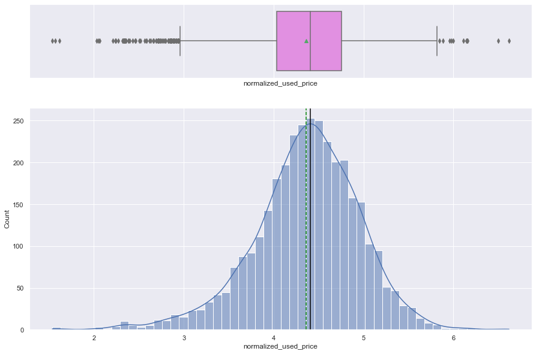

```python
#checking distribution of normalized used price
histogram_boxplot(device_data, 'normalized_used_price', kde=True)
```

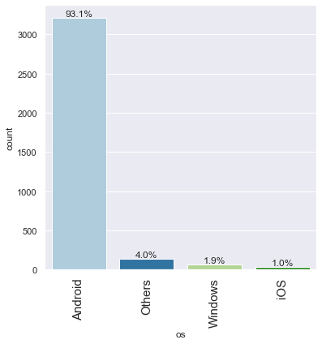

```python
#makeup of used device market by OS
labeled_barplot(device_data, 'os', perc=True)
```

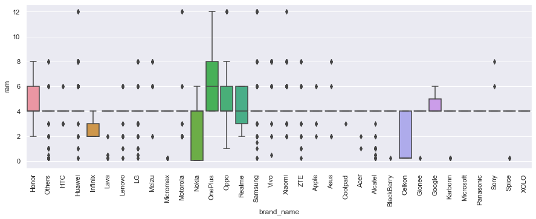

```python
#boxplot to show distribution of ram by device brand
plt.figure(figsize=(15, 5))
sns.boxplot(data=device_data, x='brand_name', y='ram')
plt.xticks(rotation=90)
plt.show()
```

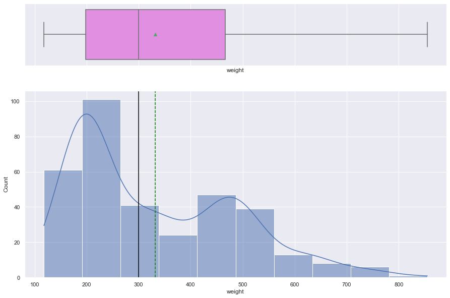

```python
#new dataframe for phones with battery larger than 4500 mAh
device_big_battery = device_data[device_data['battery'] > 4500]

#plotting the weight vs battery size for devices with large batteries
histogram_boxplot(device_big_battery, 'weight', kde=True)
```

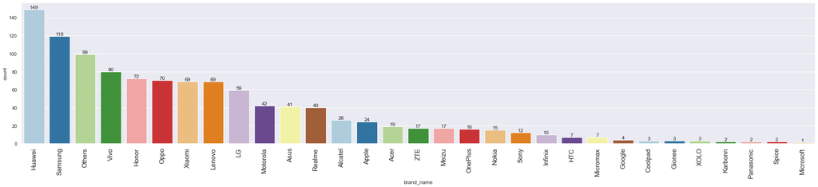

```python
#new dataframe for phones with screen size larger than 6 in or 15.24 cm
device_big_screen = device_data[device_data['screen_size'] > 15.24]

#labeled barplot
labeled_barplot(device_big_screen, 'brand_name')
```

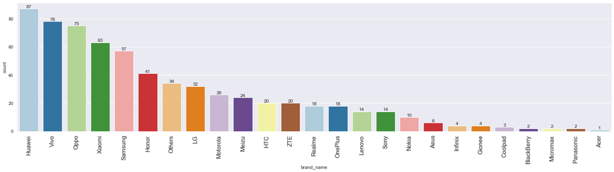

```python
#new dataframe for devices where selfie camera has more than 8 mp
selfie_8mp = device_data[device_data['selfie_camera_mp'] > 8]

#labeled barplot
labeled_barplot(selfie_8mp, 'brand_name')
```

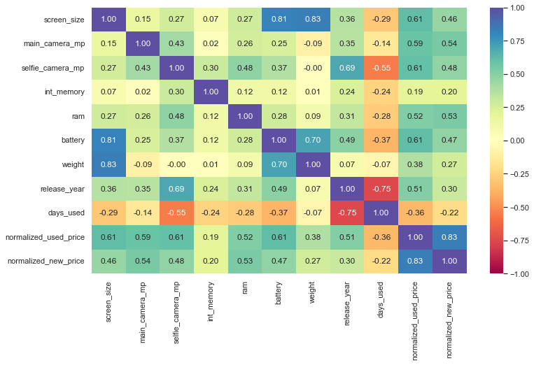

```python
#new list for numerical variables
device_num_colums = device_data.select_dtypes(include=np.number).columns.tolist()

#heatmap to show correlation between numerical variables
plt.figure(figsize=(12, 7))
sns.heatmap(
    device_data[device_num_colums].corr(), annot=True, vmin=-1, vmax=1, fmt=".2f", cmap="Spectral"
)
plt.show()
```

#### Additional Observations

- The brand_name column has a large number of values for a categorical variable. This will be promblematic when we create our dummy variables. We will likely want to group these into a few different categories - low range, mid range, and high range devices.
- As previously mentioned, there are some variables that have missing values. We need to fill these before proceeding with the model creation.

## Data Preprocessing

- Missing value treatment
- Feature engineering (if needed)
- Outlier detection and treatment (if needed)
- Preparing data for modeling
- Any other preprocessing steps (if needed)

### Missing Value Treatment

There are a few columns with missing values. We will check the distributions to see determine which value is appropriate to replace the blanks with.

```python
#checking for missing values again
device_data.isnull().sum()
```

```
brand_name                 0
os                         0
screen_size                0
4g                         0
5g                         0
main_camera_mp           179
selfie_camera_mp           2
int_memory                 4
ram                        4
battery                    6
weight                     7
release_year               0
days_used                  0
normalized_used_price      0
normalized_new_price       0
dtype: int64
```

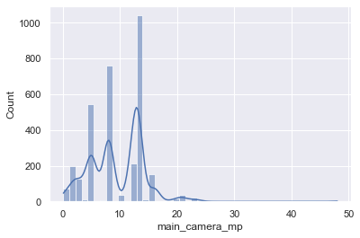

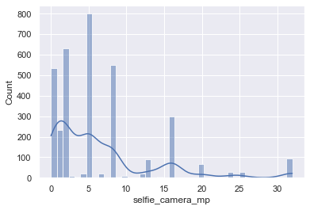

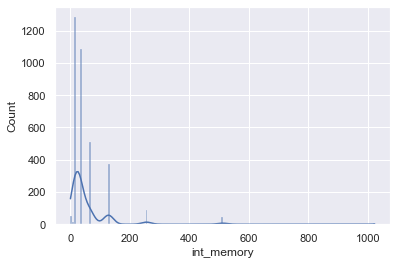

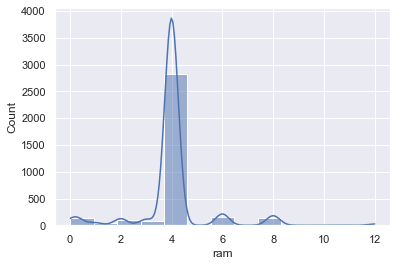

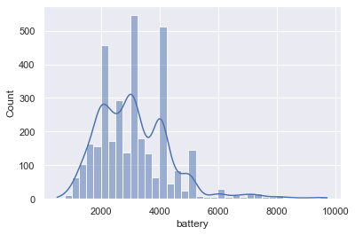

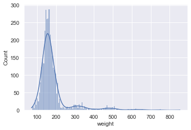

```python
#checking distribution of each of the columns with missing values to determine which value to fill it with
sns.histplot(data=device_data, x='main_camera_mp', kde=True)
plt.show()

sns.histplot(data=device_data, x='selfie_camera_mp', kde=True)
plt.show()

sns.histplot(data=device_data, x='int_memory', kde=True)
plt.show()

sns.histplot(data=device_data, x='ram', kde=True)
plt.show()

sns.histplot(data=device_data, x='battery', kde=True)
plt.show()

sns.histplot(data=device_data, x='weight', kde=True)
plt.show()
```

#### Observations

- Since none of the distributions appear to be normal, we will fill the missing values using the median instead of mean.

```python
#creating copy of dataframe for transformations
device_data_transformed = device_data.copy()
```

```python
#create list for columns that need to be imputed
device_columns_to_impute = ['main_camera_mp',
                            'selfie_camera_mp',
                            'int_memory',
                            'ram',
                            'battery',
                            'weight']

#for loop to iterate through the list of columns, replacing blanks with median grouped by brand and year of release
for col in device_columns_to_impute:
    device_data_transformed[col] = device_data_transformed[col].fillna(
        value = device_data_transformed.groupby(['brand_name','release_year'])[col].transform('median')
    )

#checking for missing values again
device_data_transformed.isnull().sum()
```

```
brand_name                 0
os                         0
screen_size                0
4g                         0
5g                         0
main_camera_mp           179
selfie_camera_mp           2
int_memory                 0
ram                        0
battery                    6
weight                     7
release_year               0
days_used                  0
normalized_used_price      0
normalized_new_price       0
dtype: int64
```

```python
#create list for columns that need to be imputed
device_columns_to_impute = ['main_camera_mp',
                            'selfie_camera_mp',
                            'battery',
                            'weight']

#for loop to iterate through the list of columns, replacing blanks with median grouped by brand
for col in device_columns_to_impute:
    device_data_transformed[col] = device_data_transformed[col].fillna(
        value = device_data_transformed.groupby(['brand_name'])[col].transform('median')
    )

#checking for missing values again
device_data_transformed.isnull().sum()
```

```
brand_name                0
os                        0
screen_size               0
4g                        0
5g                        0
main_camera_mp           10
selfie_camera_mp          0
int_memory                0
ram                       0
battery                   0
weight                    0
release_year              0
days_used                 0
normalized_used_price     0
normalized_new_price      0
dtype: int64
```

```python
#replacing blank values for main camera mp with mean from same column
device_data_transformed['main_camera_mp'] = device_data_transformed['main_camera_mp'].fillna(
    value=device_data_transformed['main_camera_mp'].median()
)

#checking for missing values again
device_data_transformed.isnull().sum()
```

```
brand_name               0
os                       0
screen_size              0
4g                       0
5g                       0
main_camera_mp           0
selfie_camera_mp         0
int_memory               0
ram                      0
battery                  0
weight                   0
release_year             0
days_used                0
normalized_used_price    0
normalized_new_price     0
dtype: int64
```

### Feature Engineering

There are a couple things we can do to make this model more effecient.

- Group the devices into three categories: high, mid, low range (replacing current brand_name value). This will make dummy variable creation and modeling the data much easier. We will base this category off of the device's normalized new price. We will replace the current brand_name value with the new value.
- Drop release_year for a column that makes more sense. We will create a new variable in its place that is the number of years since 2021. This new column is more meaningful since the person looking at the data can immediately tell what it is. Seeing 2020 or 2021 in the column does not mean much without extra context.

```
count    3454.000000
mean        5.233107
std         0.683637
min         2.901422
25%         4.790342
50%         5.245892
75%         5.673718
max         7.847841
Name: normalized_new_price, dtype: float64
```

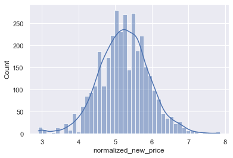

```python
#viewing stats and distribution for normalized new price to determine the breakout of the categories
sns.histplot(data=device_data_transformed, x='normalized_new_price', kde=True)

device_data_transformed['normalized_new_price'].describe()
```

```python
#devices with normalized new price between 0 and 4 are low range
device_data_transformed.loc[device_data_transformed.normalized_new_price > 0, 'brand_name'] = 'low_range'
#devices with normalized new price between 4 and 6 are mid range
device_data_transformed.loc[device_data_transformed.normalized_new_price > 4, 'brand_name'] = 'mid_range'
#devices with normalized new price greater than 6 are high range
device_data_transformed.loc[device_data_transformed.normalized_new_price > 6, 'brand_name'] = 'high_range'
```

```python
#creating new column to use in favor of release_year
device_data_transformed['age_in_years'] = 2021 - device_data_transformed['release_year']
device_data_transformed.drop('release_year', axis=1, inplace=True)
```

### Outlier Detection

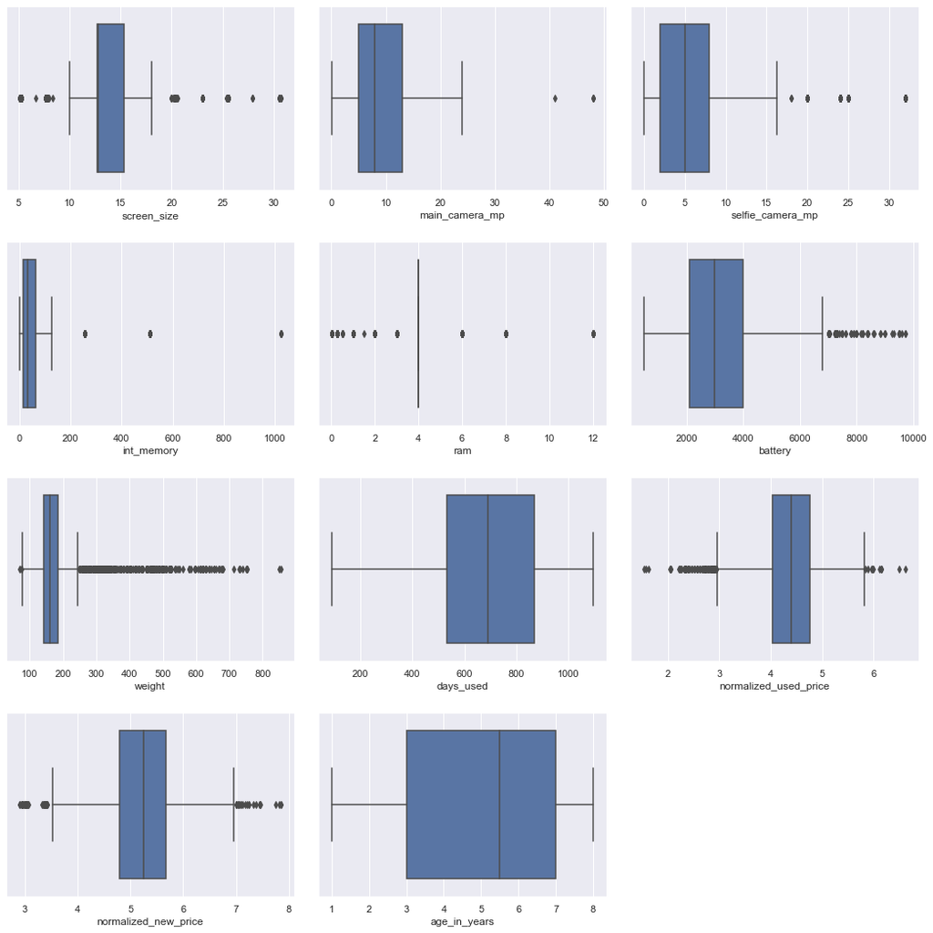

```python
# outlier detection using boxplot - code taken from SLF_MLS2_AnimeRatings.ipynb
num_cols = device_data_transformed.select_dtypes(include=np.number).columns.tolist()

plt.figure(figsize=(15, 15))

for i, variable in enumerate(num_cols):
    plt.subplot(4, 3, i + 1)
    sns.boxplot(data=device_data_transformed, x=variable)
    plt.tight_layout(pad=2)

plt.show()
```

### Preparing for Data Modeling

```python
#setting dependent and independent variables
X = device_data_transformed.drop(['normalized_used_price'], axis=1)
y = device_data_transformed['normalized_used_price']

print(X.head())
print(y.head())
```

```
  brand_name       os  screen_size   4g   5g  main_camera_mp  \
0  mid_range  Android        14.50  yes   no            13.0
1  mid_range  Android        17.30  yes  yes            13.0
2  mid_range  Android        16.69  yes  yes            13.0
3  mid_range  Android        25.50  yes  yes            13.0
4  mid_range  Android        15.32  yes   no            13.0

   selfie_camera_mp  int_memory  ram  battery  weight  days_used  \
0               5.0        64.0  3.0   3020.0   146.0        127
1              16.0       128.0  8.0   4300.0   213.0        325
2               8.0       128.0  8.0   4200.0   213.0        162
3               8.0        64.0  6.0   7250.0   480.0        345
4               8.0        64.0  3.0   5000.0   185.0        293

   normalized_new_price  age_in_years
0              4.715100             1
1              5.519018             1
2              5.884631             1
3              5.630961             1
4              4.947837             1
0    4.307572
1    5.162097
2    5.111084
3    5.135387
4    4.389995
Name: normalized_used_price, dtype: float64
```

```python
#adding intercept
X = sm.add_constant(X)

#dummy variable creation
X = pd.get_dummies(
    X,
    columns=X.select_dtypes(include=['object', 'category']).columns.tolist(),
    drop_first=True,
)

#using 70:30 split for train to test data
x_train, x_test, y_train, y_test = train_test_split(X, y, test_size=0.3, random_state=1)
```

## EDA

- Reviewing the brand_name visuals again to see if they are easier to read after feature engineering.
- We will also check the correlation heatmap to see if anything changed.

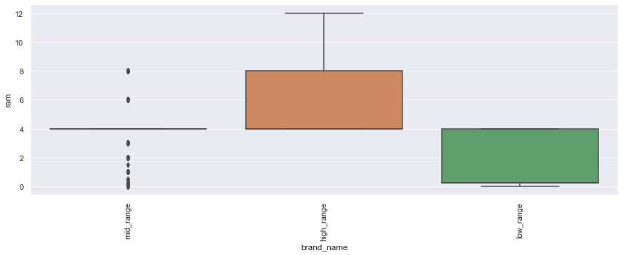

```python
#reviewing the brand_name charts again to see if they are easier to read after feature engineering

#boxplot to show distribution of ram by device brand
plt.figure(figsize=(15, 5))
sns.boxplot(data=device_data_transformed, x='brand_name', y='ram')
plt.xticks(rotation=90)
plt.show()
```

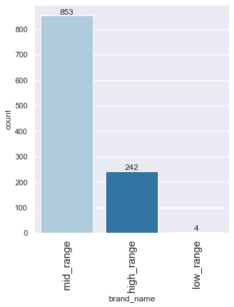

```python
#new dataframe for phones with screen size larger than 6 in or 15.24 cm
device_big_screen_transformed = device_data_transformed[device_data_transformed['screen_size'] > 15.24]

#labeled barplot
labeled_barplot(device_big_screen_transformed, 'brand_name')
```

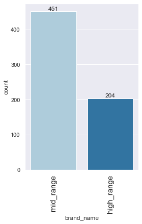

```python
#new dataframe for devices where selfie camera has more than 8 mp
selfie_8mp_transformed = device_data_transformed[device_data_transformed['selfie_camera_mp'] > 8]

#labeled barplot
labeled_barplot(selfie_8mp_transformed, 'brand_name')
```

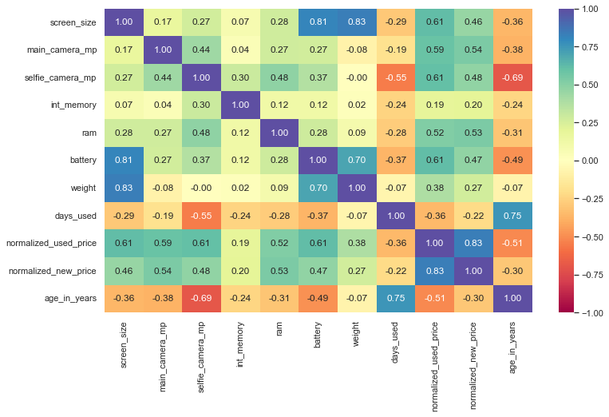

```python
#new list for numerical variables
device_num_colums_transformed = device_data_transformed.select_dtypes(include=np.number).columns.tolist()

#heatmap to show correlation between numerical variables
plt.figure(figsize=(12, 7))
sns.heatmap(
    device_data_transformed[device_num_colums_transformed].corr(), annot=True, vmin=-1, vmax=1, fmt=".2f", cmap="Spectral"
)
plt.show()
```

#### Observations

- The visuals that previously had brand name of the device are now much easier to read and generate insight on.
- Excluding some outliers, mid range devices do not have much variation in RAM. As we would expect to see, devices in the high end range have more RAM than devices in the mid and low range (again, excluding some outliers found in the mid range devices).
- There are almost four times as many mid range devices with large screen size compared to high end devices. This is expected because tablets (devices more likely to have a larger screen) typically cost less than most high end phones. There are obviously some execptions like Apple's iPad pro line, but generally flagship phones cost more than tablets.
- There are double the amount of mid range devices with large MP selfie cameras compared to high end devices. This one surprised me, but could be due to the fact that some mid range tablets have a higher quality front camera than a comparably specced phone. Another factor could be that some manufacturers like Apple, who are generally considered on the high end of the market, do not have high MP front cameras.
- The correlation between the normalized used price and other variables did not change.

## Model Building - Linear Regression

```python
#initial model
olsmodel = sm.OLS(y_train, x_train).fit()
print(olsmodel.summary())
```

```
                              OLS Regression Results
=================================================================================
Dep. Variable:     normalized_used_price   R-squared:                       0.852
Model:                               OLS   Adj. R-squared:                  0.851
Method:                    Least Squares   F-statistic:                     811.6
Date:                   Wed, 08 Jun 2022   Prob (F-statistic):               0.00
Time:                           17:33:25   Log-Likelihood:                 179.66
No. Observations:                   2417   AIC:                            -323.3
Df Residuals:                       2399   BIC:                            -219.1
Df Model:                             17
Covariance Type:               nonrobust
========================================================================================
                           coef    std err          t      P>|t|      [0.025      0.975]
----------------------------------------------------------------------------------------
const                    1.4837      0.073     20.210      0.000       1.340       1.628
screen_size              0.0191      0.003      5.853      0.000       0.013       0.025
main_camera_mp           0.0207      0.001     15.112      0.000       0.018       0.023
selfie_camera_mp         0.0143      0.001     13.611      0.000       0.012       0.016
int_memory               0.0002   6.61e-05      3.778      0.000       0.000       0.000
ram                      0.0171      0.005      3.527      0.000       0.008       0.027
battery               -7.55e-06   6.89e-06     -1.096      0.273   -2.11e-05    5.96e-06
weight                   0.0011      0.000      8.585      0.000       0.001       0.001
days_used              4.33e-05   2.95e-05      1.468      0.142   -1.45e-05       0.000
normalized_new_price     0.4023      0.014     29.419      0.000       0.375       0.429
age_in_years            -0.0266      0.004     -6.092      0.000      -0.035      -0.018
brand_name_low_range    -0.3530      0.043     -8.169      0.000      -0.438      -0.268
brand_name_mid_range     0.0553      0.021      2.691      0.007       0.015       0.096
os_Others                0.0770      0.030      2.560      0.011       0.018       0.136
os_Windows               0.0165      0.035      0.471      0.638      -0.052       0.085
os_iOS                  -0.0170      0.044     -0.391      0.696      -0.102       0.068
4g_yes                   0.0449      0.015      3.028      0.002       0.016       0.074
5g_yes                  -0.0140      0.030     -0.465      0.642      -0.073       0.045
==============================================================================
Omnibus:                      121.369   Durbin-Watson:                   1.916
Prob(Omnibus):                  0.000   Jarque-Bera (JB):              158.839
Skew:                          -0.487   Prob(JB):                     3.22e-35
Kurtosis:                       3.792   Cond. No.                     6.15e+04
==============================================================================

Notes:
[1] Standard Errors assume that the covariance matrix of the errors is correctly specified.
[2] The condition number is large, 6.15e+04. This might indicate that there are
strong multicollinearity or other numerical problems.
```

## Model Performance Check

```python
#functions below taken from SLF_MLS2_AnimeRatings.ipynb

# function to compute adjusted R-squared
def adj_r2_score(predictors, targets, predictions):
    r2 = r2_score(targets, predictions)
    n = predictors.shape[0]
    k = predictors.shape[1]
    return 1 - ((1 - r2) * (n - 1) / (n - k - 1))


# function to compute MAPE
def mape_score(targets, predictions):
    return np.mean(np.abs(targets - predictions) / targets) * 100


# function to compute different metrics to check performance of a regression model
def model_performance_regression(model, predictors, target):
    """
    Function to compute different metrics to check regression model performance

    model: regressor
    predictors: independent variables
    target: dependent variable
    """

    # predicting using the independent variables
    pred = model.predict(predictors)

    r2 = r2_score(target, pred)  # to compute R-squared
    adjr2 = adj_r2_score(predictors, target, pred)  # to compute adjusted R-squared
    rmse = np.sqrt(mean_squared_error(target, pred))  # to compute RMSE
    mae = mean_absolute_error(target, pred)  # to compute MAE
    mape = mape_score(target, pred)  # to compute MAPE

    # creating a dataframe of metrics
    df_perf = pd.DataFrame(
        {
            "RMSE": rmse,
            "MAE": mae,
            "R-squared": r2,
            "Adj. R-squared": adjr2,
            "MAPE": mape,
        },
        index=[0],
    )

    return df_perf
```

```python
#checking model performance for training set
print('Training performance\n')
training_performance = model_performance_regression(olsmodel, x_train, y_train)
training_performance
```

```
Training performance
```

|  | RMSE | MAE | R-squared | Adj. R-squared | MAPE |
| --- | --- | --- | --- | --- | --- |
| 0 | 0.224637 | 0.178923 | 0.851886 | 0.850774 | 4.26998 |

```python
#checking model performance for test set
print('Test performance\n')
test_performance = model_performance_regression(olsmodel, x_test, y_test)
test_performance
```

```
Test performance
```

|  | RMSE | MAE | R-squared | Adj. R-squared | MAPE |
| --- | --- | --- | --- | --- | --- |
| 0 | 0.229514 | 0.180507 | 0.853951 | 0.851369 | 4.366695 |

## Checking Linear Regression Assumptions

These Linear Regression assumptions will be checked:

1. No Multicollinearity
2. Linearity of variables
3. Independence of error terms
4. Normality of error terms
5. No Heteroscedasticity

### Test for Multicollinearity

```python
#import library
from statsmodels.stats.outliers_influence import variance_inflation_factor

#function to check VIF - taken from SLF_MLS2_AnimeRatings.ipynb
def checking_vif(predictors):
    vif = pd.DataFrame()
    vif["feature"] = predictors.columns

    # calculating VIF for each feature
    vif["VIF"] = [
        variance_inflation_factor(predictors.values, i)
        for i in range(len(predictors.columns))
    ]
    return vif
```

```python
checking_vif(x_train)
```

|  | feature | VIF |
| --- | --- | --- |
| 0 | const | 256.235744 |
| 1 | screen_size | 7.436320 |
| 2 | main_camera_mp | 2.009953 |
| 3 | selfie_camera_mp | 2.622580 |
| 4 | int_memory | 1.301574 |
| 5 | ram | 2.130679 |
| 6 | battery | 3.883050 |
| 7 | weight | 6.186670 |
| 8 | days_used | 2.578702 |
| 9 | normalized_new_price | 4.113892 |
| 10 | age_in_years | 4.777486 |
| 11 | brand_name_low_range | 2.668605 |
| 12 | brand_name_mid_range | 2.482695 |
| 13 | os_Others | 1.658603 |
| 14 | os_Windows | 1.023887 |
| 15 | os_iOS | 1.103120 |
| 16 | 4g_yes | 2.292470 |
| 17 | 5g_yes | 1.744848 |

#### Observations

- screen_size and weight have VIF values greater than 5, which indicates a presence of strong multicollinearity.
- These two variables will be systematically dropped.

### Removing Multicollinearity

```python
#function to systematically drop columns with VIF greater than 5 - taken from SLF_MLS2_AnimeRatings.ipynb
def treating_multicollinearity(predictors, target, high_vif_columns):
    """
    Checking the effect of dropping the columns showing high multicollinearity
    on model performance (adj. R-squared and RMSE)

    predictors: independent variables
    target: dependent variable
    high_vif_columns: columns having high VIF
    """
    # empty lists to store adj. R-squared and RMSE values
    adj_r2 = []
    rmse = []

    # build ols models by dropping one of the high VIF columns at a time
    # store the adjusted R-squared and RMSE in the lists defined previously
    for cols in high_vif_columns:
        # defining the new train set
        train = predictors.loc[:, ~predictors.columns.str.startswith(cols)]

        # create the model
        olsmodel = sm.OLS(target, train).fit()

        # adding adj. R-squared and RMSE to the lists
        adj_r2.append(olsmodel.rsquared_adj)
        rmse.append(np.sqrt(olsmodel.mse_resid))

    # creating a dataframe for the results
    temp = pd.DataFrame(
        {
            "col": high_vif_columns,
            "Adj. R-squared after_dropping col": adj_r2,
            "RMSE after dropping col": rmse,
        }
    ).sort_values(by="Adj. R-squared after_dropping col", ascending=False)
    temp.reset_index(drop=True, inplace=True)

    return temp
```

```python
column_list = ['screen_size', 'weight']
treated_device_res = treating_multicollinearity(x_train, y_train, column_list)
treated_device_res
```

|  | col | Adj. R-squared after_dropping col | RMSE after dropping col |
| --- | --- | --- | --- |
| 0 | screen_size | 0.848769 | 0.227035 |
| 1 | weight | 0.846318 | 0.228868 |

```python
#dropping screen_size column
col_to_drop = 'screen_size'
x_train2 = x_train.loc[:, ~x_train.columns.str.startswith(col_to_drop)]
x_test2 = x_test.loc[:, ~x_test.columns.str.startswith(col_to_drop)]

# Check VIF again
checking_vif(x_train2)
```

|  | feature | VIF |
| --- | --- | --- |
| 0 | const | 239.452684 |
| 1 | main_camera_mp | 2.007104 |
| 2 | selfie_camera_mp | 2.618291 |
| 3 | int_memory | 1.301431 |
| 4 | ram | 2.130472 |
| 5 | battery | 3.640901 |
| 6 | weight | 2.879740 |
| 7 | days_used | 2.566542 |
| 8 | normalized_new_price | 4.071601 |
| 9 | age_in_years | 4.604050 |
| 10 | brand_name_low_range | 2.661477 |
| 11 | brand_name_mid_range | 2.464218 |
| 12 | os_Others | 1.497438 |
| 13 | os_Windows | 1.023763 |
| 14 | os_iOS | 1.102167 |
| 15 | 4g_yes | 2.290864 |
| 16 | 5g_yes | 1.743651 |

#### Observations

- Multicollinearity has been removed with the dropping of screen_size.
- New model will be built using the new predictor variables.

```python
olsmodel2 = sm.OLS(y_train, x_train2).fit()
print(olsmodel2.summary())
```

```
                              OLS Regression Results
=================================================================================
Dep. Variable:     normalized_used_price   R-squared:                       0.850
Model:                               OLS   Adj. R-squared:                  0.849
Method:                    Least Squares   F-statistic:                     848.5
Date:                   Wed, 08 Jun 2022   Prob (F-statistic):               0.00
Time:                           17:33:25   Log-Likelihood:                 162.52
No. Observations:                   2417   AIC:                            -291.0
Df Residuals:                       2400   BIC:                            -192.6
Df Model:                             16
Covariance Type:               nonrobust
========================================================================================
                           coef    std err          t      P>|t|      [0.025      0.975]
----------------------------------------------------------------------------------------
const                    1.5937      0.071     22.302      0.000       1.454       1.734
main_camera_mp           0.0210      0.001     15.238      0.000       0.018       0.024
selfie_camera_mp         0.0146      0.001     13.764      0.000       0.013       0.017
int_memory               0.0003   6.66e-05      3.814      0.000       0.000       0.000
ram                      0.0173      0.005      3.560      0.000       0.008       0.027
battery               2.518e-06   6.72e-06      0.375      0.708   -1.07e-05    1.57e-05
weight                   0.0016   8.75e-05     18.726      0.000       0.001       0.002
days_used             3.145e-05   2.96e-05      1.061      0.289   -2.67e-05    8.96e-05
normalized_new_price     0.4104      0.014     29.961      0.000       0.384       0.437
age_in_years            -0.0315      0.004     -7.291      0.000      -0.040      -0.023
brand_name_low_range    -0.3660      0.043     -8.425      0.000      -0.451      -0.281
brand_name_mid_range     0.0657      0.021      3.186      0.001       0.025       0.106
os_Others                0.0221      0.029      0.769      0.442      -0.034       0.079
os_Windows               0.0143      0.035      0.404      0.687      -0.055       0.084
os_iOS                  -0.0245      0.044     -0.560      0.576      -0.110       0.061
4g_yes                   0.0426      0.015      2.854      0.004       0.013       0.072
5g_yes                  -0.0186      0.030     -0.615      0.539      -0.078       0.041
==============================================================================
Omnibus:                      129.263   Durbin-Watson:                   1.913
Prob(Omnibus):                  0.000   Jarque-Bera (JB):              170.317
Skew:                          -0.507   Prob(JB):                     1.04e-37
Kurtosis:                       3.814   Cond. No.                     6.00e+04
==============================================================================

Notes:
[1] Standard Errors assume that the covariance matrix of the errors is correctly specified.
[2] The condition number is large,  6e+04. This might indicate that there are
strong multicollinearity or other numerical problems.
```

#### Observations

- Adj. R-squared dropped from .851 to .849, which means that the dropped column (screen_size) did not have much impact on the model.
- Since there is no longer multicollinearity, the predictor variable p-values can be evaluated for significance.

#### Evaluating Predictor p-values

```python
#code below uses a loop to check which variables can be removed from the model based on high p-value
#taken from SLF_MLS2_AnimeRatings.ipynb

# initial list of columns
predictors = x_train2.copy()
cols = predictors.columns.tolist()

# setting an initial max p-value
max_p_value = 1

while len(cols) > 0:
    # defining the train set
    x_train_aux = predictors[cols]

    # fitting the model
    model = sm.OLS(y_train, x_train_aux).fit()

    # getting the p-values and the maximum p-value
    p_values = model.pvalues
    max_p_value = max(p_values)

    # name of the variable with maximum p-value
    feature_with_p_max = p_values.idxmax()

    if max_p_value > 0.05:
        cols.remove(feature_with_p_max)
    else:
        break

selected_features = cols
print(selected_features)
```

```
['const', 'main_camera_mp', 'selfie_camera_mp', 'int_memory', 'ram', 'weight', 'normalized_new_price', 'age_in_years', 'brand_name_low_range', 'brand_name_mid_range', '4g_yes']
```

```python
#using the output from the previous code to set new x training and test variables
x_train3 = x_train2[selected_features]
x_test3 = x_test2[selected_features]

#new model using new predictor list
olsmodel3 = sm.OLS(y_train, x_train3).fit()
print(olsmodel3.summary())
```

```
                              OLS Regression Results
=================================================================================
Dep. Variable:     normalized_used_price   R-squared:                       0.850
Model:                               OLS   Adj. R-squared:                  0.849
Method:                    Least Squares   F-statistic:                     1359.
Date:                   Wed, 08 Jun 2022   Prob (F-statistic):               0.00
Time:                           17:33:25   Log-Likelihood:                 161.22
No. Observations:                   2417   AIC:                            -300.4
Df Residuals:                       2406   BIC:                            -236.8
Df Model:                             10
Covariance Type:               nonrobust
========================================================================================
                           coef    std err          t      P>|t|      [0.025      0.975]
----------------------------------------------------------------------------------------
const                    1.6162      0.070     23.200      0.000       1.480       1.753
main_camera_mp           0.0212      0.001     15.829      0.000       0.019       0.024
selfie_camera_mp         0.0146      0.001     13.888      0.000       0.013       0.017
int_memory               0.0002    6.6e-05      3.714      0.000       0.000       0.000
ram                      0.0154      0.004      3.663      0.000       0.007       0.024
weight                   0.0017   5.84e-05     28.441      0.000       0.002       0.002
normalized_new_price     0.4088      0.013     30.429      0.000       0.382       0.435
age_in_years            -0.0288      0.003     -8.757      0.000      -0.035      -0.022
brand_name_low_range    -0.3590      0.042     -8.564      0.000      -0.441      -0.277
brand_name_mid_range     0.0670      0.020      3.305      0.001       0.027       0.107
4g_yes                   0.0454      0.015      3.096      0.002       0.017       0.074
==============================================================================
Omnibus:                      130.575   Durbin-Watson:                   1.916
Prob(Omnibus):                  0.000   Jarque-Bera (JB):              173.529
Skew:                          -0.507   Prob(JB):                     2.08e-38
Kurtosis:                       3.833   Cond. No.                     3.63e+03
==============================================================================

Notes:
[1] Standard Errors assume that the covariance matrix of the errors is correctly specified.
[2] The condition number is large, 3.63e+03. This might indicate that there are
strong multicollinearity or other numerical problems.
```

```python
#checking model performance for test set
print('Training performance\n')
training_performance3 = model_performance_regression(olsmodel3, x_train3, y_train)
training_performance3
```

```
Training performance
```

|  | RMSE | MAE | R-squared | Adj. R-squared | MAPE |
| --- | --- | --- | --- | --- | --- |
| 0 | 0.226357 | 0.179797 | 0.849609 | 0.848921 | 4.294443 |

```python
#checking model performance for test set
print('Test performance\n')
test_performance3 = model_performance_regression(olsmodel3, x_test3, y_test)
test_performance3
```

```
Test performance
```

|  | RMSE | MAE | R-squared | Adj. R-squared | MAPE |
| --- | --- | --- | --- | --- | --- |
| 0 | 0.232501 | 0.183092 | 0.850125 | 0.848517 | 4.43017 |

#### Observations

- Adjusted R-squared is the same as the previous model, meaning the variables dropped did not have much effect.
- Adjusted R-squared is .849, meaning the model can explain approximately 85% of the variance in the data.
- The p-values on the features are all less than 0.05, so we will likely be able to use x_train3 as the final set of predictor variables and olsmodel3 as the final model.
- RSME and MAE values are comparable between, which indicates that the model is not overfitting.
- R-squared is high enough that we can assume that the model is not underfitting.

### Test for Linearity and Independence

```python
#create dataframe with actual, fitted, and residual values
predictor = pd.DataFrame()

#actual values
predictor['actual'] = y_train
#predicted values
predictor['fitted'] = olsmodel3.fittedvalues
#residuals
predictor['residuals'] = olsmodel3.resid

predictor.head()
```

|  | actual | fitted | residuals |
| --- | --- | --- | --- |
| 3026 | 4.087488 | 3.881646 | 0.205842 |
| 1525 | 4.448399 | 4.598505 | -0.150105 |
| 1128 | 4.315353 | 4.298532 | 0.016820 |
| 3003 | 4.282068 | 4.195093 | 0.086975 |
| 2907 | 4.456438 | 4.505194 | -0.048756 |

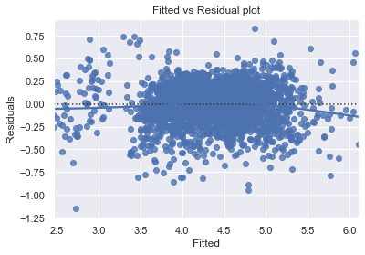

```python
#plotting the fitted values vs residuals

sns.residplot(data=predictor, x='fitted', y='residuals', lowess=True)
plt.xlabel('Fitted')
plt.ylabel('Residuals')
plt.title('Fitted vs Residual plot')
plt.show()
```

#### Observations

- The plot above does not appear to have a pattern, so the assumptions of linearity and independence are satisfied.

### Test for Normality

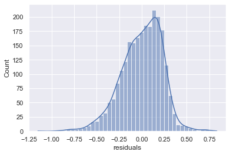

```python
#plotting the distribution of the residuals to check for normality
sns.histplot(data=predictor, x='residuals', kde=True)
plt.show()
```

#### Observations

- The residuals appear to follow an approximate normal distribution.
- We will check the Q-Q plot next.

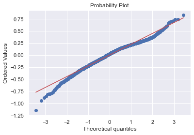

```python
#importing the libraries
import pylab
import scipy.stats as stats

#probability plot on the residuals
stats.probplot(predictor['residuals'], dist='norm', plot=pylab)
plt.show()
```

#### Observations

- With the exception of one of the tails, the residuals roughly follow a straight line.
- The Shapiro-Wilk test results will be checked next.

```python
stats.shapiro(predictor['residuals'])
```

```
ShapiroResult(statistic=0.9810248017311096, pvalue=1.9573918941977116e-17)
```

#### Observations

- Since the p-value < 0.05, we can determine that the residuals are not normal per the Shapiro-Wilk test.
- However, the distribution is approximately normal.
- Therefore, this assumption is satisfied.

### Test for Homoscedasticity

```python
#importing the libraries
import statsmodels.stats.api as sms
from statsmodels.compat import lzip

name = ['F statistic', 'p-value']
test = sms.het_goldfeldquandt(predictor['residuals'], x_train3)
lzip(name, test)
```

```
[('F statistic', 1.0701316986203449), ('p-value', 0.12050885949772543)]
```

#### Observations

- Since the p-value > 0.05, the residuals are homoscedastic. This assumption is satisified.

### Predictions on Test Data

```python
#checking some predictions on the test set against their actual values
predicted_values = olsmodel3.predict(x_test3)

predicted_values_df = pd.DataFrame({'Actual': y_test, 'Predicted': predicted_values})
predicted_values_df.sample(10, random_state=1)
```

|  | Actual | Predicted |
| --- | --- | --- |
| 1995 | 4.566741 | 4.402983 |
| 2341 | 3.696103 | 4.014863 |
| 1913 | 3.592093 | 3.667274 |
| 688 | 4.306495 | 4.111037 |
| 650 | 4.522115 | 5.093281 |
| 2291 | 4.259294 | 4.395718 |
| 40 | 4.997685 | 5.381049 |
| 1884 | 3.875359 | 4.065247 |
| 2538 | 4.206631 | 4.067411 |
| 45 | 5.380450 | 5.211063 |

#### Observations

- The model has returned good prediction results as the actual and predicted values are close.

## Final Model

```python
#setting final training and test predictors
x_train_final = x_train3.copy()
x_test_final = x_test3.copy()

#creating final model
olsmodel_final = sm.OLS(y_train, x_train_final).fit()
print(olsmodel_final.summary())
```

```
                              OLS Regression Results
=================================================================================
Dep. Variable:     normalized_used_price   R-squared:                       0.850
Model:                               OLS   Adj. R-squared:                  0.849
Method:                    Least Squares   F-statistic:                     1359.
Date:                   Wed, 08 Jun 2022   Prob (F-statistic):               0.00
Time:                           17:33:26   Log-Likelihood:                 161.22
No. Observations:                   2417   AIC:                            -300.4
Df Residuals:                       2406   BIC:                            -236.8
Df Model:                             10
Covariance Type:               nonrobust
========================================================================================
                           coef    std err          t      P>|t|      [0.025      0.975]
----------------------------------------------------------------------------------------
const                    1.6162      0.070     23.200      0.000       1.480       1.753
main_camera_mp           0.0212      0.001     15.829      0.000       0.019       0.024
selfie_camera_mp         0.0146      0.001     13.888      0.000       0.013       0.017
int_memory               0.0002    6.6e-05      3.714      0.000       0.000       0.000
ram                      0.0154      0.004      3.663      0.000       0.007       0.024
weight                   0.0017   5.84e-05     28.441      0.000       0.002       0.002
normalized_new_price     0.4088      0.013     30.429      0.000       0.382       0.435
age_in_years            -0.0288      0.003     -8.757      0.000      -0.035      -0.022
brand_name_low_range    -0.3590      0.042     -8.564      0.000      -0.441      -0.277
brand_name_mid_range     0.0670      0.020      3.305      0.001       0.027       0.107
4g_yes                   0.0454      0.015      3.096      0.002       0.017       0.074
==============================================================================
Omnibus:                      130.575   Durbin-Watson:                   1.916
Prob(Omnibus):                  0.000   Jarque-Bera (JB):              173.529
Skew:                          -0.507   Prob(JB):                     2.08e-38
Kurtosis:                       3.833   Cond. No.                     3.63e+03
==============================================================================

Notes:
[1] Standard Errors assume that the covariance matrix of the errors is correctly specified.
[2] The condition number is large, 3.63e+03. This might indicate that there are
strong multicollinearity or other numerical problems.
```

```python
#checking model performance for final training set
print('Training performance\n')
train_performance_final = model_performance_regression(olsmodel_final, x_train_final, y_train)
train_performance_final
```

```
Training performance
```

|  | RMSE | MAE | R-squared | Adj. R-squared | MAPE |
| --- | --- | --- | --- | --- | --- |
| 0 | 0.226357 | 0.179797 | 0.849609 | 0.848921 | 4.294443 |

```python
#checking model performance for test set
print('Test performance\n')
test_performance_final = model_performance_regression(olsmodel_final, x_test_final, y_test)
test_performance_final
```

```
Test performance
```

|  | RMSE | MAE | R-squared | Adj. R-squared | MAPE |
| --- | --- | --- | --- | --- | --- |
| 0 | 0.232501 | 0.183092 | 0.850125 | 0.848517 | 4.43017 |

## Actionable Insights and Recommendations

- The model is able to explain ~85% of the variation in the data and predict within ~4.43% of the normalized used price.
- Main camera megapixels, normalized new price, and 4g capability are the biggest drivers in the normalized used price.
- Devices that are at least one year old and devices that are considered "low range" have the biggest detractor to used price.
- ReCell can maximize its profits by trying to focus on acquring newer, mid/high range, 4g capable devices. These devices will yield the highest used price for ReCell.
- Devices with a higher quality selfie camera are also highly sought by buyers in the used market.